# Module R’Stat1 : Rappels (4/4)

francois.rebaudo@ird.fr

Novembre 2019 ; IRD-Montpellier-France CC BY-NC-ND 3.0

# Rappels : un peu d’algorithmique

## Conditions avec `if`

## Conditions avec `if`

**SI** [*cela*] **ALORS** [*cela*] **SINON** [*cela*]

## Conditions avec `if`

```r
myVar <- 2
if(myVar < 3){
  print("myVar < 3")
}else{
  print("myVar >= 3")
}
```

```
## [1] "myVar < 3"
```

## Conditions avec `if`

```r
myVar <- TRUE
if(is.character(myVar)){
  print("myVar: character")
} else {
  if(is.numeric(myVar)){
    print("myVar: numeric")
  } else {
    if(is.logical(myVar)){
      print("myVar: logical")
    } else {
      print("myVar: ...")
    }
  }
}
```

```
## [1] "myVar: logical"
```

## Conditions avec `if`

`if` n’évalue que le premier élément :

```r
# mauvais code !!!
prueba <- c(TRUE, FALSE, FALSE)
if(prueba == TRUE){
  print("vrai")
}
```

```
## [1] "vrai"
```

## Conditions avec `if`

`if` n’évalue que le premier élément :

```r
prueba <- c(TRUE, FALSE, FALSE)
if(prueba[1] == TRUE){
  print("vrai (1)")
}
```

```
## [1] "vrai (1)"
```

```r
if(prueba[2] == TRUE){
  print("vrai (2)")
}
```

## Conditions avec `if`

```r
prueba <- c(TRUE, FALSE, FALSE)
if(prueba[1] == TRUE &
    prueba[2] == TRUE &
    prueba[3] == TRUE){
  print("vrai")
}
```

## Conditions avec `if`

```r
prueba <- c(TRUE, FALSE, FALSE)
if(sum(prueba == TRUE) == length(prueba)){
  print("vrai")
}
```

## Conditions avec `if`

```r
prueba <- c(TRUE, TRUE, TRUE)
if(sum(prueba == TRUE) == length(prueba)){
  print("vrai")
}
```

```
## [1] "vrai"
```

## `&` y `&&`

`&` : toutes les conditions

`&&` : la première condition et les suivantes si la première est vraie.

```r
miNumero <- 9
if(is.numeric(miNumero) & miNumero * 10 < 100){
  print("Numéro < 10")
}
```

```
## [1] "Numéro < 10"
```

## `&` y `&&`

```r
miNumero <- "55"
if(is.numeric(miNumero) & miNumero * 10 < 100){
  print("Numéro < 10")
}
```

```
## Error in miNumero * 10: argument non numérique pour un opérateur binaire
```

## `&` y `&&`

```r
miNumero <- "55"
if(is.numeric(miNumero) && miNumero * 10 < 100){
  print("Numéro < 10")
}
```

## Boucles `for`

## Boucles `for`

```r
bdd <- data.frame(rep01 = rnorm(n = 100, mean = 10, sd = 1),
                  rep02 = rnorm(n = 100, mean = 10, sd = 1))
print(head(bdd))
```

```
##       rep01     rep02
## 1  9.922518  9.388914
## 2  9.763272 10.363430
## 3 10.126622  8.706250
## 4 10.532272  8.633082
## 5 11.226414  9.911668
## 6  9.576858 11.637517
```

## Boucles `for`

```r
for (i in 1:5){
  print(bdd$rep01[i] - bdd$rep02[i])
}
```

```
## [1] 0.5336036
## [1] -0.6001578
## [1] 1.420372
## [1] 1.89919
## [1] 1.314747
```

## Boucles `for`

```r
letras <- letters
for (i in seq_along(letras)){
  if(letras[i] %in% c("a", "e", "i", "o", "u", "y")){
    print(paste0("voyelle ", letras[i]," en position: ", i))
  }
}
```

```
## [1] "voyelle a en position: 1"
## [1] "voyelle e en position: 5"
## [1] "voyelle i en position: 9"
## [1] "voyelle o en position: 15"
## [1] "voyelle u en position: 21"
## [1] "voyelle y en position: 25"
```

## Boucles `for` et `R`

R ne gère pas bien les boucles `for`. Nous verrons plus tard comment utiliser des alternatives. En attendant, lorsque cela est possible, le travail avec des vecteurs devrait être préféré.

La plupart des exemples que l’on peut trouver sur Internet à propos de la boucle `for` peuvent être remplacés par des opérations vectorielles.

## Boucles `for`

```r
# [1] FOR
for (i in 1:5){
  print(bdd$rep01[i] - bdd$rep02[i])
}
```

```
## [1] 0.5336036
## [1] -0.6001578
## [1] 1.420372
## [1] 1.89919
## [1] 1.314747
```

```r
# [2] VECTOR
head(bdd$rep01 - bdd$rep02)
```

```
## [1]  0.5336036 -0.6001578  1.4203723  1.8991897  1.3147469 -2.0606591
```

## Boucles `for`

```r
letras <- letters
# [1] FOR
for (i in seq_along(letras)){
  if(letras[i] %in% c("a", "e", "i", "o", "u", "y")){
    print(paste0("voyelle ", letras[i]," en position: ", i))
  }
}
```

```
## [1] "voyelle a en position: 1"
## [1] "voyelle e en position: 5"
## [1] "voyelle i en position: 9"
## [1] "voyelle o en position: 15"
## [1] "voyelle u en position: 21"
## [1] "voyelle y en position: 25"
```

```r
# [2] VECTOR
which(letras %in% c("a", "e", "i", "o", "u", "y"))
```

```
## [1]  1  5  9 15 21 25
```

## Boucles `for`

```r
# nombre de nombres pairs
# [1] FOR
x <- sample(1:100, size = 20)
count <- 0
for (val in x) {
  if(val %% 2 == 0){
    count <- count + 1
  }
}
print(count)
```

```
## [1] 15
```

```r
# [2] VECTOR
sum(x %% 2 == 0)
```

```
## [1] 15
```

## Boucles `for`

```r
# calculer des valeurs au carré
# [1] FOR
x <- rep(0, 20)
for (j in 1:20){
  x[j] <- j^2
}
print(x)
```

```
##  [1]   1   4   9  16  25  36  49  64  81 100 121 144 169 196 225 256 289
## [18] 324 361 400
```

```r
# [2] VECTOR
(1:20)^2
```

```
##  [1]   1   4   9  16  25  36  49  64  81 100 121 144 169 196 225 256 289
## [18] 324 361 400
```

## Boucles `for`

```r
# tirs de dés
# [1] FOR
ntrials = 1000
trials = rep(0, ntrials)
for (j in 1:ntrials){
  trials[j] = sample(1:6, size = 1)
}
mean(trials)
```

```
## [1] 3.532
```

```r
# [2] VECTOR
mean(sample(1:6, ntrials, replace = TRUE))
```

```
## [1] 3.55
```

## Boucles `for`

C’est un bon exercice que d’explorer les nombreux exemples disponibles sur Internet sur la boucle `for` et d’essayer de les convertir en opérations vectorielles. Cela nous permet d’acquérir de bons réflexes de programmation avec R.

En conclusion, il est recommandé de ne pas utiliser la boucle `for` avec R aussi souvent que possible. Dans ce cours, nous verrons des alternatives telles que les boucles de la famille `apply`.

## Boucles `while`

```r
i <- 0
while(i < 4){
  print(i)
  i <- i + 1
}
```

```
## [1] 0
## [1] 1
## [1] 2
## [1] 3
```

## Boucles `while`

```r
myNumber <- sample(x = 10000, size = 1)
myGuess <- sample(x = 10000, size = 1)
paste0("Mon numéro secret: ", myNumber)
```

```
## [1] "Mon numéro secret: 3312"
```

```r
paste0("L'essai de l'ordinateur: ", myGuess)
```

```
## [1] "L'essai de l'ordinateur: 1871"
```

## Boucles `while`

```r
startTime <- Sys.time()
print(startTime)
```

```
## [1] "2019-10-03 16:15:22 CEST"
```

## Boucles `while`

```r
print(Sys.time() - startTime)
```

```
## Time difference of 0.0499711 secs
```

## Boucles `while`

```r
repeticiones <- 0
startTime <- Sys.time()
while(Sys.time() - startTime < 0.5){
  repeticiones <- repeticiones + 1
}
print(repeticiones)
```

```
## [1] 10847
```

## Boucles `while`

```r
repeticiones <- 0
startTime <- Sys.time()
while(Sys.time() - startTime < 0.5){
  repeticiones <- repeticiones + 1
  if(repeticiones >= 1000){
    break
  }
}
print(repeticiones)
```

```
## [1] 1000
```

## Boucles `while`

```r
myNumber <- sample(x = 10000, size = 1)
myGuess <- sample(x = 10000, size = 1)
numberGuess <- 0
startTime <- Sys.time()
while(Sys.time() - startTime < 2){
  if(myGuess == myNumber){
    numberGuess <- numberGuess + 1
    print(paste0("Numéro trouvé après ",
      numberGuess, " essais."))
    print(paste0("Et il me reste plein de temps : ",
      round(2 - as.numeric(Sys.time() - startTime),
      digits = 2), " sec"))
    break
  }else{
    myGuess <- sample(x = 10000, size = 1)
    numberGuess <- numberGuess + 1
  }
}
```

```
## [1] "Numéro trouvé après 1785 essais."
## [1] "Et il me reste plein de temps : 1.89 sec"
```

## Boucles de la famille `apply`

## `apply`

```r
bdd <- matrix(rnorm(200), ncol = 20)
print(bdd)
```

```
##               [,1]        [,2]       [,3]         [,4]       [,5]
##  [1,] -0.765678500 -0.67369120 -2.1656093 -0.006290591  0.1578879
##  [2,] -0.392481315  0.01624043  1.6515738 -0.963538630  0.5536493
##  [3,]  0.050797999  0.60440895  1.5157684  1.012658241  1.6332417
##  [4,]  0.517874266 -1.64967892 -0.6950825 -0.514417550  0.3131771
##  [5,]  1.295112262  1.27512866  2.5339502 -0.345414096 -0.4773363
##  [6,]  1.201171895 -0.80655164  0.7211207 -1.168795153  0.3637982
##  [7,] -0.004658158 -0.81436182  1.1036037 -1.476007842 -0.7272571
##  [8,]  0.117754340 -1.21829151  0.7102438  1.934248526 -0.6153481
##  [9,] -1.095758521 -1.49092506  0.2937126 -1.123399259 -0.6011720
## [10,]  0.587269667  0.52809171  0.4336630  0.714323346 -0.4448704
##             [,6]       [,7]       [,8]        [,9]      [,10]        [,11]
##  [1,] -0.1574574  1.7784757 -0.1362339  0.75346327 -0.5188087  0.379799300
##  [2,]  0.1286711  0.8491819 -0.5670995 -0.31280233  1.6058993  0.041667907
##  [3,] -1.2179146  0.4523584 -1.1252471  0.70388775 -1.0472165 -0.659861566
```

[output cut: 29 more lines]

## `apply`

```r
apply(bdd, MARGIN = 2, FUN = mean)
```

```
##  [1]  0.15114039 -0.42296304  0.61029443 -0.19366330  0.01557701
##  [6] -0.29995847  0.13490067 -0.27374466  0.54332733 -0.24514797
## [11]  0.03074586  0.06415907  0.01034146 -1.07658982  0.05827029
## [16] -0.07917269 -0.28204147  0.20338547 -0.01357253  0.04835218
```

## `apply`

```r
apply(bdd, MARGIN = 1, FUN = median)
```

```
##  [1] -0.10424461  0.02895417  0.01847133 -0.14703597  0.03021394
##  [6]  0.37710357 -0.13795608  0.04489832 -0.86166861  0.17826304
```

## `apply`

```r
bdd <- matrix(sample(c(1:20, NA), size = 200, replace = TRUE),
  ncol = 20)
apply(bdd, MARGIN = 2, FUN = mean)
```

```
##  [1] 10.0   NA  9.3  9.8   NA   NA  9.0  7.0 12.8   NA  9.2   NA 15.3   NA
## [15] 12.3   NA 11.2   NA   NA  6.3
```

## `apply`

```r
apply(bdd, MARGIN = 2, FUN = mean, na.rm = TRUE)
```

```
##  [1] 10.000000  6.125000  9.300000  9.800000 11.000000 11.666667  9.000000
##  [8]  7.000000 12.800000  9.666667  9.200000  9.888889 15.300000 10.666667
## [15] 12.300000 12.333333 11.200000 12.875000 11.333333  6.300000
```

## `apply`

```r
apply(bdd, MARGIN = 2, FUN = function(i){
  mean(i, na.rm = TRUE)
})
```

```
##  [1] 10.000000  6.125000  9.300000  9.800000 11.000000 11.666667  9.000000
##  [8]  7.000000 12.800000  9.666667  9.200000  9.888889 15.300000 10.666667
## [15] 12.300000 12.333333 11.200000 12.875000 11.333333  6.300000
```

## `lapply`

```r
myList <- list(
  a = sample(1:100, size = 10),
  b = sample(1:100, size = 10),
  c = sample(1:100, size = 10),
  d = sample(1:100, size = 10),
  e = sample(1:100, size = 10)
)
print(myList)
```

```
## $a
##  [1] 71 13 91 32  1 79 73  6 46 84
##
## $b
##  [1] 13 84  6 46 15 80  1 32 30 69
##
## $c
##  [1] 52 79 31 87 86 46 11 12 62 60
##
## $d
##  [1]  67  79  86  26  81  70 100  75  47   9
##
## $e
##  [1] 82 48 74 62 85 57 44 43 80 16
```

## `lapply`

```r
lapply(myList, FUN = mean)
```

```
## $a
## [1] 49.6
##
## $b
## [1] 37.6
##
## $c
## [1] 52.6
##
## $d
## [1] 64
##
## $e
## [1] 59.1
```

## `lapply`

```r
myList <- list(
  a = sample(c(1:5, NA), size = 10, replace = TRUE),
  b = sample(c(1:5, NA), size = 10, replace = TRUE),
  c = sample(c(1:5, NA), size = 10, replace = TRUE),
  d = sample(c(1:5, NA), size = 10, replace = TRUE),
  e = sample(c(1:5, NA), size = 10, replace = TRUE)
)
print(myList)
```

```
## $a
##  [1] NA  3  2  1 NA  5  4  5  1  3
##
## $b
##  [1]  5  3 NA NA  1 NA  3  1 NA  1
##
## $c
##  [1]  1  3 NA  2  1  2  2  3 NA NA
##
## $d
##  [1]  4 NA  1  3  5  3  1  5  3  1
##
## $e
##  [1]  3  2  5  5  5  4  3  3 NA  2
```

## `lapply`

```r
lapply(myList, FUN = mean)
```

```
## $a
## [1] NA
##
## $b
## [1] NA
##
## $c
## [1] NA
##
## $d
## [1] NA
##
## $e
## [1] NA
```

## `lapply`

```r
lapply(myList, FUN = mean, na.rm = TRUE)
```

```
## $a
## [1] 3
##
## $b
## [1] 2.333333
##
## $c
## [1] 2
##
## $d
## [1] 2.888889
##
## $e
## [1] 3.555556
```

## `lapply`

```r
lapply(myList, FUN = function(i){
  mean(i, na.rm = TRUE)
})
```

```
## $a
## [1] 3
##
## $b
## [1] 2.333333
##
## $c
## [1] 2
##
## $d
## [1] 2.888889
##
## $e
## [1] 3.555556
```

## `lapply`

```r
lapply(myList, FUN = function(i){
  m <- mean(i, na.rm = TRUE)
  if(m > 3){
    return("grand")
  }else{
    return("petit")
  }
})
```

```
## $a
## [1] "petit"
##
## $b
## [1] "petit"
##
## $c
## [1] "petit"
##
## $d
## [1] "petit"
##
## $e
## [1] "grand"
```

## `lapply`

Nombre de données manquantes

```r
lapply(myList, FUN = function(i){
  sum(is.na(i))
})
```

```
## $a
## [1] 2
##
## $b
## [1] 4
##
## $c
## [1] 3
##
## $d
## [1] 1
##
## $e
## [1] 1
```

## `sapply`

```r
lapply(myList, FUN = function(i){
  sum(is.na(i))
})
```

```
## $a
## [1] 2
##
## $b
## [1] 4
##
## $c
## [1] 3
##
## $d
## [1] 1
##
## $e
## [1] 1
```

## `sapply`

```r
sapply(myList, FUN = function(i){
  sum(is.na(i))
})
```

```
## a b c d e
## 2 4 3 1 1
```

## `sapply`

```r
sapply(myList, FUN = '[[', 2)
```

```
##  a  b  c  d  e
##  3  3  3 NA  2
```

## `sapply`

```r
myDF <- data.frame(
  a = sample(c(1:5, NA), size = 10, replace = TRUE),
  b = sample(c(1:5, NA), size = 10, replace = TRUE),
  c = sample(c(1:5, NA), size = 10, replace = TRUE),
  d = sample(c(1:5, NA), size = 10, replace = TRUE),
  e = sample(c(1:5, NA), size = 10, replace = TRUE)
)
print(myDF)
```

```
##     a  b  c d  e
## 1  NA  4  3 4  4
## 2   1  2  4 3  5
## 3  NA  4  3 2  5
## 4   3  4 NA 2  5
## 5   3  1 NA 2  3
## 6   5 NA  1 4  3
## 7   2  4  5 2 NA
## 8   1  2  1 1 NA
## 9   4  4  3 4 NA
## 10  2  5  2 5  2
```

## `sapply`

```r
sapply(myDF, FUN = function(i){
  sum(is.na(i))
})
```

```
## a b c d e
## 2 1 2 0 3
```

## `sapply`

```r
pruebaTiempo <- lapply(
  seq(from = 1000, to = 5000, by = 1000),
  function(sampleSize){
  sapply(1:5, function(repet){
    startTime <- Sys.time()
    guessNumber(mySample = 1:sampleSize)
    return(Sys.time() - startTime)
  })
})
```

[output not shown]

## `sapply`

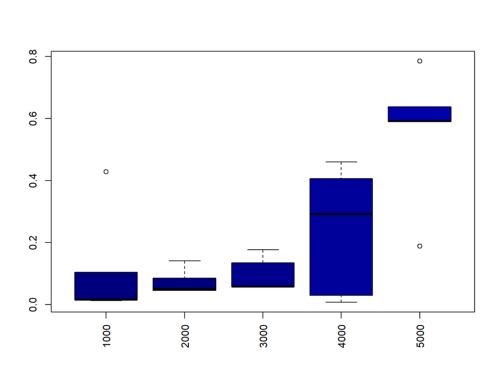

## `tapply`

```r
col0 <- sample(LETTERS[1:5], size = 1000, replace = TRUE)
col1 <- rnorm(n = 1000, mean = 10, sd = 0.5)
col2 <- rlnorm(n = 1000, meanlog = 10, sdlog = 0.5)
col3 <- rgamma(n = 1000, shape = 10, rate = 0.5)
dfCol <- data.frame(col0, col1, col2, col3)
print(head(dfCol, n = 10))
```

```
##    col0      col1      col2     col3
## 1     D  9.342874 45293.746 25.35815
## 2     A  9.751796 12577.267 15.64159
## 3     E 10.540578 11141.242 28.58087
## 4     B  9.534572 27562.190 14.32539
## 5     E 10.570737  9522.016 28.08649
## 6     A  9.441922 34658.559 19.85533
## 7     A 10.506382 24397.736 14.96653
## 8     A 10.109506 12841.923 21.42310
## 9     B 10.516283 22761.873 14.01590
## 10    B  9.487621 21817.316 27.89437
```

## `tapply`

```r
tapply(dfCol$col1, INDEX = dfCol$col0, FUN = summary)
```

```
## $A
##    Min. 1st Qu.  Median    Mean 3rd Qu.    Max.
##   8.879   9.699  10.057  10.048  10.409  11.406
##
## $B
##    Min. 1st Qu.  Median    Mean 3rd Qu.    Max.
##   8.495   9.639  10.031   9.994  10.367  11.594
##
## $C
##    Min. 1st Qu.  Median    Mean 3rd Qu.    Max.
##   8.281   9.692  10.029  10.021  10.363  11.219
##
## $D
##    Min. 1st Qu.  Median    Mean 3rd Qu.    Max.
##   8.419   9.733  10.084  10.051  10.410  11.342
##
## $E
##    Min. 1st Qu.  Median    Mean 3rd Qu.    Max.
##   8.961   9.624  10.007  10.013  10.342  11.505
```

## `tapply`

```r
sapply(2:4, FUN = function(i){
  tapply(dfCol[,i], INDEX = dfCol$col0, FUN = mean)
})
```

```
##        [,1]     [,2]     [,3]
## A 10.048172 24646.62 19.86288
## B  9.993861 24899.61 18.95589
## C 10.021235 24542.52 19.82570
## D 10.051203 25866.84 20.15909
## E 10.012768 25846.31 20.64797
```

# Rappels : écrire une fonction

## Fonction

```r
maFonctionPlus2 <- function(x){
  res <- x + 2
  return(res)
}
maFonctionPlus2(x = 3)
```

```
## [1] 5
```